# Additive Models, Trees and Related Methods:

Now we will discuss some specific methods for supervised learning. these techniques each assume a (different) structured form for the unknown regression function, and by doing so they finesse the curse of dimensionality. Ofcourse, they pay the possible price of misspecifying the model, and so in each case there is a trade-off that has to be made.

### Generalized Additive Models:

Regression models play an important role in many data analyses, providing prediction and classification rules, and data analytic tools for understanding the importance of different inputs.  
In real life effects are often non linear. Here we will describe more automatic flexible statistical methods that may be used to identify and characterize non linear regression effects. These methods are called "Generalized Additive Models".  
In regression setting, a generalized additive model has the form,  
$E[Y|X] = \alpha + f_{1}(X_{1})+....+f_{p}(X_{p})$  
The $f_{j}$'s are unspecified smooth functions. We fit each function using a scatterplot smoother (e.g. cubic smoothing spline or kernel smoother) , and provide an algorithm for simultaneously estimating all p functions.  
In general, the conditional mean $\mu$(x) of a response Y is related to an additive function of the predictors via a link function g,  
$g[\mu (x)] = \alpha +f_{1}(X_{1})+....+f_{p}(X_{p}) $  
Examples of classical link functions are the following:

- $g(\mu) = \mu$ is the identity link , used for linear and additive models for gaussian response data.
- $g(\mu) = logit(\mu) $ or $ probit (\mu)$, for modeling binomial probabilities.
- $g(\mu) = log(\mu) $ for log-linear or log-additive models for poisson count data

[figure not shown]

Here $S_{j}$ implies fitting a natural cubic spline on the data specified in the argument.

[figure not shown]

#### Example: Predicting Email Spam

The data for this example consists of information from 4601 email messages, in a study to try to predict whether the email was junk email, or “spam.” The objective was to design an automatic spam detector that could filter out spam before clogging the users’ mailboxes. For all 4601 email messages, the true outcome (email type) email or spam is available, along with the relative frequencies of 57 of the most commonly occurring words and punctuation marks in the email message

```python
import pandas as pd
from matplotlib import transforms, pyplot as plt
import numpy as np
from sklearn.metrics import accuracy_score
import pygam


np.seterr(divide='ignore', invalid='ignore')
np.warnings.filterwarnings('ignore')
%matplotlib inline




# we will calculate train and test error rates for all models
def error_rate(y_true, y_pred):
    return 1 - accuracy_score(y_true, y_pred)
```

```python
cd C:\Machine Learning\Datasets
```

```
C:\Machine Learning\Datasets
```

```python
df = pd.read_csv("Spam.txt")
df.head()
```

|  | test | word_freq_make | word_freq_address | word_freq_all | word_freq_3d | word_freq_our | word_freq_over | word_freq_remove | word_freq_internet | word_freq_order | ... | char_freq_; | char_freq_( | char_freq_[ | char_freq_! | char_freq_$ | char_freq_# | capital_run_length_average | capital_run_length_longest | capital_run_length_total | spam |
| --- | --- | --- | --- | --- | --- | --- | --- | --- | --- | --- | --- | --- | --- | --- | --- | --- | --- | --- | --- | --- | --- |
| 0 | 1 | 0.00 | 0.64 | 0.64 | 0.0 | 0.32 | 0.00 | 0.00 | 0.00 | 0.00 | ... | 0.00 | 0.000 | 0.0 | 0.778 | 0.000 | 0.000 | 3.756 | 61 | 278 | 1 |
| 1 | 0 | 0.21 | 0.28 | 0.50 | 0.0 | 0.14 | 0.28 | 0.21 | 0.07 | 0.00 | ... | 0.00 | 0.132 | 0.0 | 0.372 | 0.180 | 0.048 | 5.114 | 101 | 1028 | 1 |
| 2 | 1 | 0.06 | 0.00 | 0.71 | 0.0 | 1.23 | 0.19 | 0.19 | 0.12 | 0.64 | ... | 0.01 | 0.143 | 0.0 | 0.276 | 0.184 | 0.010 | 9.821 | 485 | 2259 | 1 |
| 3 | 0 | 0.00 | 0.00 | 0.00 | 0.0 | 0.63 | 0.00 | 0.31 | 0.63 | 0.31 | ... | 0.00 | 0.137 | 0.0 | 0.137 | 0.000 | 0.000 | 3.537 | 40 | 191 | 1 |
| 4 | 0 | 0.00 | 0.00 | 0.00 | 0.0 | 0.63 | 0.00 | 0.31 | 0.63 | 0.31 | ... | 0.00 | 0.135 | 0.0 | 0.135 | 0.000 | 0.000 | 3.537 | 40 | 191 | 1 |

5 rows × 59 columns

```python
#We coded spam as 1 and email as 0. A test set of size 1536 was
#randomly chosen, leaving 3065 observations in the training set.
target = 'spam'
columns = ['word_freq_make', 'word_freq_address', 'word_freq_all',
           'word_freq_3d', 'word_freq_our', 'word_freq_over',
           'word_freq_remove', 'word_freq_internet', 'word_freq_order',
           'word_freq_mail', 'word_freq_receive', 'word_freq_will',
           'word_freq_people', 'word_freq_report', 'word_freq_addresses',
           'word_freq_free', 'word_freq_business', 'word_freq_email',
           'word_freq_you', 'word_freq_credit', 'word_freq_your',
           'word_freq_font', 'word_freq_000', 'word_freq_money',
           'word_freq_hp', 'word_freq_hpl', 'word_freq_george',
           'word_freq_650', 'word_freq_lab', 'word_freq_labs',
           'word_freq_telnet', 'word_freq_857', 'word_freq_data',
           'word_freq_415', 'word_freq_85', 'word_freq_technology',
           'word_freq_1999', 'word_freq_parts', 'word_freq_pm',
           'word_freq_direct', 'word_freq_cs', 'word_freq_meeting',
           'word_freq_original', 'word_freq_project', 'word_freq_re',
           'word_freq_edu', 'word_freq_table', 'word_freq_conference',
           'char_freq_;', 'char_freq_(', 'char_freq_[', 'char_freq_!',
           'char_freq_$', 'char_freq_#', 'capital_run_length_average',
           'capital_run_length_longest', 'capital_run_length_total']
# let's give columns more compact names
features = ['make', 'address', 'all', '3d', 'our', 'over', 'remove',
            'internet', 'order', 'mail', 'receive', 'will', 'people',
            'report', 'addresses', 'free', 'business', 'email', 'you',
            'credit', 'your', 'font', '000', 'money', 'hp', 'hpl',
            'george', '650', 'lab', 'labs', 'telnet', '857', 'data',
            '415', '85', 'technology', '1999', 'parts', 'pm', 'direct',
            'cs', 'meeting', 'original', 'project', 're', 'edu', 'table',
            'conference', 'ch_;', 'ch(', 'ch[', 'ch!', 'ch$', 'ch#',
            'CAPAVE', 'CAPMAX', 'CAPTOT']

X, y = df[columns].values, df[target].values

# split by test column value
is_test = df.test.values
X_train, X_test = X[is_test == 0], X[is_test == 1]
y_train, y_test = y[is_test == 0], y[is_test == 1]
```

```python
#Logistic Regression
import statsmodels.api as sm
from sklearn.metrics import accuracy_score
```

```python
lr_clf = sm.Logit(y_train, sm.add_constant(X_train)).fit(disp=False)
# 0.5 is a threshold
y_test_hat = (lr_clf.predict(sm.add_constant(X_test)) > 0.5).astype(int)
lr_error_rate = error_rate(y_test, y_test_hat)
print(f'Logistic Regression Test Error Rate: {lr_error_rate*100:.1f}%')
```

```
Logistic Regression Test Error Rate: 7.6%
```

```python
#GAM
import pygam
from pygam import LogisticGAM
from sklearn.metrics import confusion_matrix
```

```python
# NOTE. With this lambda values we get about 4 df for predictors.
lam = np.array([1.00e+06, 5.00e+02, 5.00e+02, 1.00e-01, 5.00e+03,  # 1-5
                1.64e+02, 4.16e+01, 4.00e+01, 8.00e+01, 1.64e+02,  # 6-10
                1.64e+02, 3.28e+02, 1.64e+02, 8.26e+01, 4.16e+01,  # 11-15
                1.64e+02, 8.26e+01, 1.64e+02, 3.28e+02, 4.16e+01,  # 16-20
                3.28e+02, 1.09e+01, 2.11e+01, 4.16e+01, 2.11e+01,  # 21-25
                1.09e+01, 7.00e-01, 1.09e+01, 7.00e-01, 1.09e+01,  # 26-30
                3.25e+00, 7.00e-01, 2.11e+01, 1.00e-01, 5.81e+00,  # 31-35
                4.16e+01, 8.26e+01, 1.97e+00, 1.09e+01, 8.26e+01,  # 36-40
                1.00e-02, 8.50e-01, 1.00e+00, 5.81e+00, 8.26e+01,  # 41-45
                1.09e+01, 1.00e+00, 1.00e+00, 8.26e+01, 8.26e+01,  # 46-50
                2.11e+01, 1.64e+02, 1.00e+00, 1.00e-01, 1.00e+01,  # 51-55
                1.00e-02, 1.00e-02])                               # 56-57
```

```python
X_train_log = np.log(X_train+0.1)
X_test_log = np.log(X_test+0.1)
gam_clf = LogisticGAM(lam=lam).fit(X_train_log, y_train)
```

```python
y_test_hat = gam_clf.predict(X_test_log)
cm = 100*confusion_matrix(y_test, y_test_hat)/y_test.shape[0]
print(f'           |   Predicted Class  ')
print(f'           |----------------------')
print(f'True Class | email (0)  spam (1)')
print(f'----------------------------------')
print(f'email (0)  |     {cm[0,0]:.1f}%     {cm[0,1]:.1f}%')
print(f'spam (1)   |      {cm[1,0]:.1f}%    {cm[1,1]:.1f}%')
gam_error_rate = error_rate(y_test, y_test_hat)
print(f'\nGAM Test Error Rate: {gam_error_rate*100:.1f}%')
```

```
           |   Predicted Class
           |----------------------
True Class | email (0)  spam (1)
----------------------------------
email (0)  |     58.6%     2.7%
spam (1)   |      2.6%    36.1%

GAM Test Error Rate: 5.3%
```

```python
# refit linear logistic model to log-transformed features
lr_clf = sm.Logit(y_train, sm.add_constant(X_train_log)).fit(disp=False)
# calculate z-values for the linear logistic model
cov = lr_clf.cov_params()
std_err = np.sqrt(np.diag(cov))
z_values = lr_clf.params / std_err

# PAGE 302. TABLE 9.2. Significant predictors from the additive model fit to
#           the spam training data.
print('Name      Num.   df  Coefficient  Std. Error  Z Score  P-value')
print('-----------------------------------------------------------------')
print('                       Positive effects')
for p in ['our', 'over', 'remove', 'internet', 'free', 'business', 'hpl',
          'ch!', 'ch$', 'CAPMAX', 'CAPTOT', 'hp', 'george', '1999', 're',
          'edu']:
    if p == 'hp':
        print('                       Negative effects')
    idx = features.index(p)
    coef_indices = gam_clf.terms.get_coef_indices(idx)
    edof = gam_clf.statistics_['edof_per_coef'][coef_indices].sum()
    cf = lr_clf.params[idx+1]
    print(f'{p:<10}{idx+1:>3}{edof:>6.1f}{cf:>10.3f}{std_err[idx+1]:>13.3f}'
          f'{z_values[idx+1]:>10.3f}{lr_clf.pvalues[idx+1]:>9.3}')
```

```
Name      Num.   df  Coefficient  Std. Error  Z Score  P-value
-----------------------------------------------------------------
                       Positive effects
our         5   4.1     0.444        0.091     4.899 9.65e-07
over        6   3.9     0.198        0.159     1.246    0.213
remove      7   3.7     0.950        0.161     5.908 3.47e-09
internet    8   3.8     0.424        0.150     2.835  0.00458
free       16   3.1     0.506        0.098     5.174 2.29e-07
business   17   3.0     0.604        0.153     3.939  8.2e-05
hpl        26   2.3     0.027        0.202     0.135    0.892
ch!        52   1.5     0.754        0.102     7.372 1.68e-13
ch$        53   1.4     1.421        0.227     6.261 3.82e-10
CAPMAX     56   2.5     0.056        0.187     0.298    0.766
CAPTOT     57   3.3     0.572        0.138     4.149 3.33e-05
                       Negative effects
hp         25   3.0    -1.348        0.195    -6.898 5.28e-12
george     27   2.2    -3.966        0.707    -5.609 2.03e-08
1999       37   1.8    -0.385        0.156    -2.469   0.0136
re         45   1.5    -0.509        0.110    -4.642 3.44e-06
edu        46   1.4    -0.993        0.196    -5.077 3.84e-07
```

```python
def dependance_plot(ax, idx, ylim):
    X_grid = gam_clf.generate_X_grid(term=idx)
    pdep, confi = gam_clf.partial_dependence(term=idx, X=X_grid, width=0.95)
    ax.plot(np.exp(X_grid[:, idx])-0.1, pdep, color='#56B4E9', linewidth=0.9)
    for e in ax.get_yticklabels() + ax.get_xticklabels():
        e.set_fontsize(4)
    ax.set_ylabel(f'f({features[idx]})',  fontsize=6)
    ax.set_xlabel(f'{features[idx]}', fontsize=6)
    ax.set_ylim(ylim)
    ax.yaxis.set_label_coords(-0.2, 0.5)
    ax.xaxis.set_label_coords(0.5, -0.15)
```

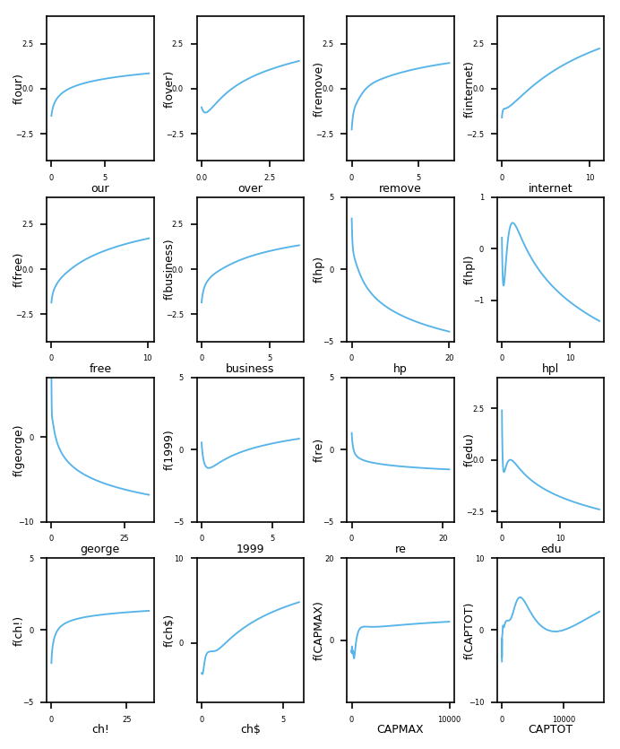

```python
fig, axarr = plt.subplots(4, 4, figsize=(5.355, 6.75), dpi=150)
plt.subplots_adjust(wspace=0.4, hspace=0.25)

# feature indices with y-lims
plots = [[(4, (-4, 4)),   (5, (-4, 4)),   (6, (-4, 4)),    (7, (-4, 4))],
         [(15, (-4, 4)),  (16, (-4, 4)),  (24, (-5, 5)),   (25, (-1.8, 1))],
         [(26, (-10, 7)), (36, (-5, 5)),  (44, (-5, 5)),   (45, (-3, 4))],
         [(51, (-5, 5)),  (52, (-7, 10)), (55, (-15, 20)), (56, (-10, 10))]]
for i in range(4):
    for j in range(4):
        dependance_plot(axarr[i, j], *plots[i][j])
```

#### Another Example:

```
100% (11 of 11) |########################| Elapsed Time: 0:00:00 Time:  0:00:00
```

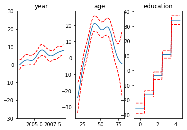

```python
from pygam import LinearGAM, s, f
from pygam.datasets import wage

X, y = wage(return_X_y=True)

## model
gam = LinearGAM(s(0) + s(1) + f(2))
gam.gridsearch(X, y)


## plotting
plt.figure();
fig, axs = plt.subplots(1,3);

titles = ['year', 'age', 'education']
for i, ax in enumerate(axs):
    XX = gam.generate_X_grid(term=i)
    ax.plot(XX[:, i], gam.partial_dependence(term=i, X=XX))
    ax.plot(XX[:, i], gam.partial_dependence(term=i, X=XX, width=.95)[1], c='r', ls='--')
    if i == 0:
        ax.set_ylim(-30,30)
    ax.set_title(titles[i]);
```

```python
gam.summary()
```

```
LinearGAM
=============================================== ==========================================================
Distribution:                        NormalDist Effective DoF:                                     19.2602
Link Function:                     IdentityLink Log Likelihood:                                -24116.7451
Number of Samples:                         3000 AIC:                                            48274.0107
                                                AICc:                                           48274.2999
                                                GCV:                                             1250.3656
                                                Scale:                                           1235.9245
                                                Pseudo R-Squared:                                   0.2945
==========================================================================================================
Feature Function                  Lambda               Rank         EDoF         P > x        Sig. Code
================================= ==================== ============ ============ ============ ============
s(0)                              [15.8489]            20           6.9          5.52e-03     **
s(1)                              [15.8489]            20           8.5          1.11e-16     ***
f(2)                              [15.8489]            5            3.8          1.11e-16     ***
intercept                                              1            0.0          1.11e-16     ***
==========================================================================================================
Significance codes:  0 '***' 0.001 '**' 0.01 '*' 0.05 '.' 0.1 ' ' 1

WARNING: Fitting splines and a linear function to a feature introduces a model identifiability problem
         which can cause p-values to appear significant when they are not.

WARNING: p-values calculated in this manner behave correctly for un-penalized models or models with
         known smoothing parameters, but when smoothing parameters have been estimated, the p-values
         are typically lower than they should be, meaning that the tests reject the null too readily.
```

```
100% (11 of 11) |########################| Elapsed Time: 0:00:00 Time:  0:00:00
```

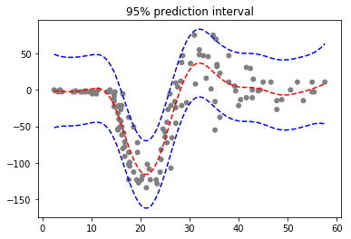

```python
#With Linear GAM we can also check for prediction interval
from pygam import LinearGAM
from pygam.datasets import mcycle

X, y = mcycle(return_X_y=True)

gam = LinearGAM(n_splines=25).gridsearch(X, y)
XX = gam.generate_X_grid(term=0, n=500)

plt.plot(XX, gam.predict(XX), 'r--')
plt.plot(XX, gam.prediction_intervals(XX, width=.95), color='b', ls='--')

plt.scatter(X, y, facecolor='gray', edgecolors='none')
plt.title('95% prediction interval');
```

```
100% (11 of 11) |########################| Elapsed Time: 0:00:00 Time:  0:00:00
```

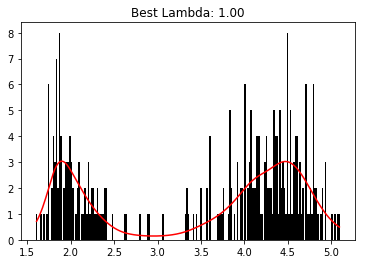

```python
#Poisson GAM
from pygam import PoissonGAM
from pygam.datasets import faithful

X, y = faithful(return_X_y=True)

gam = PoissonGAM().gridsearch(X, y)

plt.hist(faithful(return_X_y=False)['eruptions'], bins=200, color='k');
plt.plot(X, gam.predict(X), color='r')
plt.title('Best Lambda: {0:.2f}'.format(gam.lam[0][0]));
```

#### Summary:

Additive models provide an useful extension of linear models , making them more flexible while still retaining much of their interpretability. However, additive models can have limitations for large data-mining applications. The backfitting algorithm fits all predictors, which is not feasible or desirable when a large number are available.

### Tree-Based Methods:

Tree based methods partition the feature space into a set of rectangles and then fit a simple model in each one. They are conceptually simple yet powerful.

#### Regression Trees:

We now turn to the question of how to grow a regression tree. Our data consists of p inputs and a response, for each of N observations: That is $(x_{i},y_{i})$, i = 1(1)N with $x_{i} = (x_{i1},x_{i2},.....,x_{ip})$  
The algorithm needs to automatically decide on the splitting variable and split points, and also what topology (shape) the tree should have. Suppose first that we have a partition into M regions $R_{1},....,R_{M}$, and we model the response as a constant $c_{m}$ in each region:

[figure not shown]

For each splitting variable, the determination of the split point s can be done very quickly and hence by scanning through all of the inputs, determination of the best pair (j, s) is feasible.  
Having found the best split, we partition the data into the two resulting regions and repeat the splitting process on each of the two regions. Then this process is repeated on all of the resulting regions.  
Now this is obvious that a very large tree might overfit the data, while a small tree might not capture the important structure. Tree size is a tuning parameter governing the model's complexity, and the optimal tree size should be adaptively chosen from the data.

#### Classification Trees:

If the target is a classifcation outcome taking values 1,2,..K the only changes needed in the tree algorithm pertain to the criteria of splitting nodes and pruning the tree.

#### Example

```python
from sklearn import tree
from sklearn.model_selection import GridSearchCV, KFold
from typing import Union, List
```

##### Cross-Validation Tree Size Selection

Decision tree for this example in the book is selected using the approach based on "one-standard-error-rule":

- For each parameter value, perform K-fold cross-validation.
- Calculate the cross-validation error rate and its standard error.
- Find the best model, its cross-validation error rate and its standard error.
- Find the least complex tree with cross-validation error rate within one standard error of the best.

```python
class OneStandardErrorRuleModel:
    """Select the least complex model within one standard error of the best.
    Parameters
    ----------
        estimator :
            A regression or a classification model to be parametrized.
        param_name :
            The parameter of the model to be chosen by cross-validation.
        param_values :
            The values for the parameter in order of increasing complexity.
        force_model_idx :
            The preselected model index. Sometimes it is useful to run the
            process but to select the specified in advance model.
        n_folds :
            The number of folds for cross-validation.
        is_regression :
            True for a regression model, False for a classification model.
        random_state :
            The seed of the pseudo random number generator.
    Attributes
    ----------
        cv_mean_errors_ :
            Mean CV error for each parameter value.
        cv_mean_errors_std_ :
            Standard error of mean CV error for each parameter value.
        best_model_idx_ :
            The index of the param_values on which minimal mean error achieved.
        cv_min_error_ :
            Mean CV error for the best param_values.
        cv_min_error_std_ :
            Standard error of mean CV error for the best param_values.
        model_idx_ :
            The index of the model selected by "one standard error rule".
        model_ :
            The regression model retrained with selected parameter.
    """
    def __init__(self, estimator, param_name: str, param_values: List[float],
                 force_model_idx: int=None, n_folds: int=10,
                 is_regression: bool=True, random_state: int=69438):
        self.n_folds = n_folds
        self.estimator = estimator
        self.param_name = param_name
        self.param_values = param_values
        self.force_model_idx = force_model_idx
        self.is_regression = is_regression
        # neg_mean_squared_error for regression and accuracy for classification
        self.grid_search = GridSearchCV(
            estimator, {param_name: param_values},
            cv=KFold(n_folds, True, random_state),
            scoring='neg_mean_squared_error' if is_regression else 'accuracy',
            return_train_score=True, iid=True)

    def fit(self, X: np.ndarray, y: np.array) -> 'OneStandardErrorRuleModel':
        self.grid_search.fit(X, y)
        # convert score to mean squared error for regression and to error rate
        # for classification
        cv_errors = -np.vstack(
            [self.grid_search.cv_results_[f'split{i}_test_score']
             for i in range(self.n_folds)]).T
        if not self.is_regression:
            cv_errors = 1 + cv_errors
        # calculate mean error for parameters and their standard error
        self.cv_mean_errors_ = np.mean(cv_errors, axis=1)
        self.cv_mean_errors_std_ = \
            np.std(cv_errors, ddof=1, axis=1) / np.sqrt(self.n_folds)

        # find the best model
        self.best_model_idx_ = np.argmin(self.cv_mean_errors_)
        self.cv_min_error_ = self.cv_mean_errors_[self.best_model_idx_]
        self.cv_min_error_std_ = self.cv_mean_errors_std_[self.best_model_idx_]
        # find the least complex model within one standard error of the best
        error_threshold = self.cv_min_error_ + self.cv_min_error_std_
        self.model_idx_ = np.argmax(self.cv_mean_errors_ < error_threshold)
        return self.__fit_to_all_data(X, y)

    def refit(self, X: np.ndarray, y: np.array,
              force_model_idx: int=None) -> 'OneStandardErrorRuleModel':
        self.force_model_idx = force_model_idx
        return self.__fit_to_all_data(X, y)

    def __fit_to_all_data(self, X, y):
        if self.force_model_idx is not None:
            self.model_idx_ = self.force_model_idx
        self.model_ = self.estimator
        self.model_.set_params(
            **{self.param_name: self.param_values[self.model_idx_]})
        self.model_.fit(X, y)
        return self

    def predict(self, X: np.ndarray) -> np.ndarray:
        return np.squeeze(self.model_.predict(X))

    def assess(self, X: np.ndarray, y: np.array) -> (float, float):
        """Calculate mean error of the model and its standard error on the
           specified data."""
        y_hat = self.predict(X)
        errors = (y-y_hat)**2 if self.is_regression else 1.0*(y != y_hat)
        error = np.mean(errors)
        error_std = np.std(errors, ddof=1) / np.sqrt(y.size)
        return error, error_std
```

```python
max_leaf_nodes = [2, 3, 4, 5, 6, 7, 8, 9, 10, 17, 18, 21, 26, 30, 33, 37, 42]
tree_based_clf = OneStandardErrorRuleModel(
    tree.DecisionTreeClassifier(criterion='entropy', random_state=5),
    'max_leaf_nodes', max_leaf_nodes,
    is_regression=False, random_state=26,
).fit(X_train, y_train)
print(f'Selected max_leaf_nodes: {tree_based_clf.model_.max_leaf_nodes}')
print(f'Test error rate: {tree_based_clf.assess(X_test, y_test)[0]*100:.1f}%')

# calculate test error rate for each parameter value
test_error_rates = [
    tree_based_clf.refit(X_train, y_train, i).assess(X_test, y_test)[0]
    for i in range(len(max_leaf_nodes))]
```

```
Selected max_leaf_nodes: 26
Test error rate: 8.1%
```

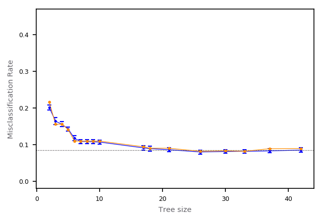

```python
ORANGE, BLUE, PURPLE = '#FF8C00', '#0000FF', '#A020F0'
GRAY1, GRAY4, GRAY7 = '#231F20', '#646369', '#929497'

fig, ax = plt.subplots(figsize=(4.75, 3.15), dpi=150)
ax.plot(max_leaf_nodes, tree_based_clf.cv_mean_errors_, c=BLUE, linewidth=0.6)
ax.errorbar(max_leaf_nodes, tree_based_clf.cv_mean_errors_,
            color=BLUE, linestyle='None', marker='o', elinewidth=0.2,
            markersize=1.5, yerr=tree_based_clf.cv_mean_errors_std_,
            ecolor=BLUE, capsize=2)
ax.axhline(y=tree_based_clf.cv_min_error_ + tree_based_clf.cv_min_error_std_,
           c=GRAY1, linewidth=0.6, linestyle=':')
for e in ax.get_yticklabels() + ax.get_xticklabels():
    e.set_fontsize(6)
ax.set_xlabel('Tree size', color=GRAY4, fontsize=7)
ax.set_ylabel('Misclassification Rate', color=GRAY4, fontsize=7)
ax.scatter(max_leaf_nodes, test_error_rates, color=ORANGE,
           s=3, zorder=10)
ax.plot(max_leaf_nodes, test_error_rates, color=ORANGE,
        linewidth=0.6)
_ = ax.set_ylim(-0.02, 0.47)
```

```python
tree_based_clf.refit(X_train, y_train, 12)
y_test_hat = tree_based_clf.predict(X_test)
tree_error_rate = tree_based_clf.assess(X_test, y_test)[0]


cm = 100*confusion_matrix(y_test, y_test_hat)/y_test.shape[0]
print(f'       |     Predicted  ')
print(f'       |----------------')
print(f'True   | email     spam ')
print(f'------------------------')
print(f'email  | {cm[0,0]:.1f}%     {cm[0,1]:.1f}%')
print(f'spam   |  {cm[1,0]:.1f}%    {cm[1,1]:.1f}%')
print(f'\nDecision Tree Test Error Rate: {tree_error_rate*100:.1f}%')
```

```
       |     Predicted
       |----------------
True   | email     spam
------------------------
email  | 57.4%     3.8%
spam   |  4.3%    34.4%

Decision Tree Test Error Rate: 8.1%
```

```python
from sklearn.metrics import roc_auc_score, roc_curve
from sklearn.metrics.ranking import _binary_clf_curve
```

```python
def spec_sens_curve(y_true, probas_pred):
    fpr, tpr, _ = roc_curve(y_true, probas_pred)
    # specificity equals to 1 - false positive rate
    return 1 - fpr, tpr
```

```python
wtree_clf = tree.DecisionTreeClassifier(
    max_leaf_nodes=17,
    criterion='entropy',
    class_weight={0: 20, 1: 1}
).fit(X_train, y_train)
```

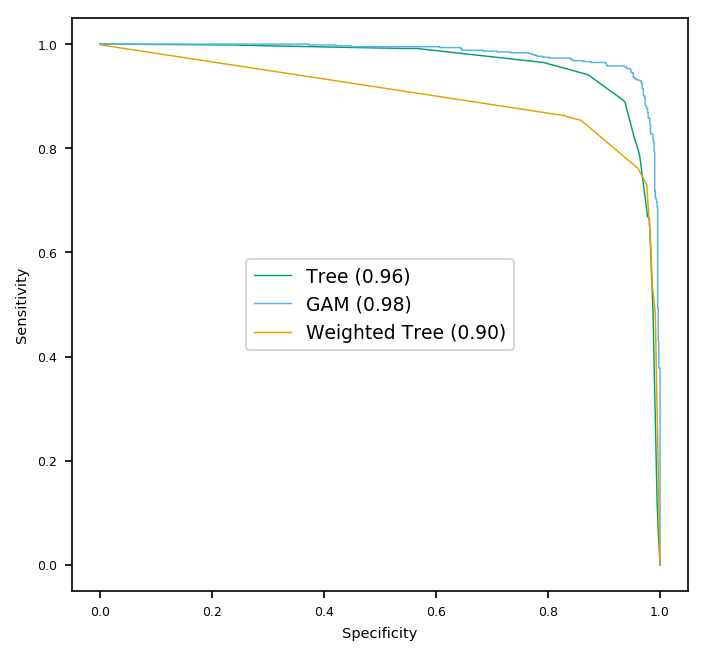

```python
gam_proba = gam_clf.predict_proba(X_test_log)
tree_proba = tree_based_clf.model_.predict_proba(X_test)[:, 1]
wtree_proba = wtree_clf.predict_proba(X_test)[:, 1]
gam_specificity, gam_sensitivity, = spec_sens_curve(y_test, gam_proba)
tree_specificity, tree_sensitivity, = spec_sens_curve(y_test, tree_proba)
wtree_specificity, wtree_sensitivity, = spec_sens_curve(y_test, wtree_proba)
gam_auc = roc_auc_score(y_test, gam_proba)
tree_auc = roc_auc_score(y_test, tree_proba)
wtree_auc = roc_auc_score(y_test, wtree_proba)

fig, ax = plt.subplots(figsize=(5.3, 5.06), dpi=150)
ax.plot(tree_specificity, tree_sensitivity, color='#009E73', linewidth=0.7,
        label=f'Tree ({tree_auc:.2f})')
ax.plot(gam_specificity, gam_sensitivity, color='#56B4E9', linewidth=0.7,
        label=f'GAM ({gam_auc:.2f})')
ax.plot(wtree_specificity, wtree_sensitivity, color='#E69F00', linewidth=0.7,
        label=f'Weighted Tree ({wtree_auc:.2f})')
for i in ax.get_yticklabels() + ax.get_xticklabels():
    i.set_fontsize(6)
ax.set_xlabel('Specificity',  fontsize=7)
ax.set_ylabel('Sensitivity',  fontsize=7)
_ = ax.legend(loc='center', prop={'size': 9})
```

### PRIM-Bump Hunting

Tree based methods partition the feature space into box-shaped region, to try to make the response averages in each box as different as possible. The splitting rules defining the boxes are related to each through a binary tree, facilitating the interpretation.  
The patient rule induction method (PRIM) also finds boxes in the feature space , but seeks boxes in which the response avergage is high. Hence it looks for maxima in the target function, an excercise known as bump hunting.

[figure not shown]

R Code is provided in the R section

### MARS: Multivariate Adaptive Regression Splines

MARS is an adaptive procedure for regression, and is well suited for high dimensional problems. It can be viewed as a generalization of stepwise linear regression or a modification of the CART method. The model has the form:  
$f(X) = \beta _{0} + \sum \beta _{m}h_{m}(X)$  
where each $h_{m}$ is a function in $C$:

[figure not shown]

or a product of two or more such functions. In general this model typically overfits the data and so a backward deletion procedure is applied. The first term whose removal causes the smallest increase in residual error is deleted from the model at each stage, producing an estimated best model and we continue in this way. R code is provided in the R section

### Hierarchical Mixture of Experts:

The Hierarchical Mixture of Experts (HME) procedure can be viewed as a variant of tree based methods. The main difference is that the tree splits are not hard decisions but rather soft probabilistic ones. The soft splits might also help in prediction accuracy and provide a useful alternative description of the data. In an HME, a linear (or logistic regression) model is fit in each terminal node, instead of a constant as in CART.  
Details of HME will be provided in the R section </p>